# Project Python Foundations: FoodHub Data Analysis

**Marks: 60**

### Context

The number of restaurants in New York is increasing day by day. Lots of students and busy professionals rely on those restaurants due to their hectic lifestyles. Online food delivery service is a great option for them. It provides them with good food from their favorite restaurants. A food aggregator company FoodHub offers access to multiple restaurants through a single smartphone app.

The app allows the restaurants to receive a direct online order from a customer. The app assigns a delivery person from the company to pick up the order after it is confirmed by the restaurant. The delivery person then uses the map to reach the restaurant and waits for the food package. Once the food package is handed over to the delivery person, he/she confirms the pick-up in the app and travels to the customer's location to deliver the food. The delivery person confirms the drop-off in the app after delivering the food package to the customer. The customer can rate the order in the app. The food aggregator earns money by collecting a fixed margin of the delivery order from the restaurants.

### Objective

The food aggregator company has stored the data of the different orders made by the registered customers in their online portal. They want to analyze the data to get a fair idea about the demand of different restaurants which will help them in enhancing their customer experience. Suppose you are hired as a Data Scientist in this company and the Data Science team has shared some of the key questions that need to be answered. Perform the data analysis to find answers to these questions that will help the company to improve the business.

### Data Description

The data contains the different data related to a food order. The detailed data dictionary is given below.

### Data Dictionary

- order_id: Unique ID of the order
- customer_id: ID of the customer who ordered the food
- restaurant_name: Name of the restaurant
- cuisine_type: Cuisine ordered by the customer
- cost_of_the_order: Cost of the order
- day_of_the_week: Indicates whether the order is placed on a weekday or weekend (The weekday is from Monday to Friday and the weekend is Saturday and Sunday)
- rating: Rating given by the customer out of 5
- food_preparation_time: Time (in minutes) taken by the restaurant to prepare the food. This is calculated by taking the difference between the timestamps of the restaurant's order confirmation and the delivery person's pick-up confirmation.
- delivery_time: Time (in minutes) taken by the delivery person to deliver the food package. This is calculated by taking the difference between the timestamps of the delivery person's pick-up confirmation and drop-off information

### Let us start by importing the required libraries

```python
# import libraries for data manipulation
import numpy as np
import pandas as pd

# import libraries for data visualization
import matplotlib.pyplot as plt
import seaborn as sns
import plotly.express as px

# Command to tell Python to actually display the graphs
%matplotlib inline
```

### Understanding the structure of the data

```python
# Run the following lines for Google Colab
from google.colab import drive
drive.mount('/content/drive')
```

```python
# Read the data
df = pd.read_csv('/content/drive/My Drive/Data Analytics Essentials program files/3. Data-Driven Insights Using Python/Project 1: Food Hub/foodhub_order.csv')
# Returns the first 5 rows
df.head()
```

|  | order_id | customer_id | restaurant_name | cuisine_type | cost_of_the_order | day_of_the_week | rating | food_preparation_time | delivery_time |
| --- | --- | --- | --- | --- | --- | --- | --- | --- | --- |
| 0 | 1477147 | 337525 | Hangawi | Korean | 30.75 | Weekend | Not given | 25 | 20 |
| 1 | 1477685 | 358141 | Blue Ribbon Sushi Izakaya | Japanese | 12.08 | Weekend | Not given | 25 | 23 |
| 2 | 1477070 | 66393 | Cafe Habana | Mexican | 12.23 | Weekday | 5 | 23 | 28 |
| 3 | 1477334 | 106968 | Blue Ribbon Fried Chicken | American | 29.20 | Weekend | 3 | 25 | 15 |
| 4 | 1478249 | 76942 | Dirty Bird to Go | American | 11.59 | Weekday | 4 | 25 | 24 |

#### Observations:

The DataFrame has 9 columns as mentioned in the Data Dictionary. Data in each row corresponds to the order placed by a customer.

### **Question 1:** How many rows and columns are present in the data? [0.5 mark]

```python
# Find dimensions of data frame
df.shape
```

```
(1898, 9)
```

#### Observations:

There are 1,898 rows and 9 columns in the data.

### **Question 2:** What are the datatypes of the different columns in the dataset? (The info() function can be used) [0.5 mark]

```python
# Use info() to print a concise summary of the DataFrame
df.info()
```

```
<class 'pandas.core.frame.DataFrame'>
RangeIndex: 1898 entries, 0 to 1897
Data columns (total 9 columns):
 #   Column                 Non-Null Count  Dtype
---  ------                 --------------  -----
 0   order_id               1898 non-null   int64
 1   customer_id            1898 non-null   int64
 2   restaurant_name        1898 non-null   object
 3   cuisine_type           1898 non-null   object
 4   cost_of_the_order      1898 non-null   float64
 5   day_of_the_week        1898 non-null   object
 6   rating                 1898 non-null   object
 7   food_preparation_time  1898 non-null   int64
 8   delivery_time          1898 non-null   int64
dtypes: float64(1), int64(4), object(4)
memory usage: 133.6+ KB
```

#### Observations:

There are 4 columns (`order_id`, `customer_id`, `food_preparation_time`, and `delivery_time`) that are integer types with 64 bits of memory.

There are 4 columns (`restaurant_name`, `cuisine_type`, `day_of_the_week`, and `rating`) of type object (string), and 1 column (`cost_of_the_order`) that is a floating-point type with 64 bits of memory.

### **Question 3:** Are there any missing values in the data? If yes, treat them using an appropriate method. [1 mark]

```python
# Creating a copy data frame before doing any treatments
df2 = df.copy()
```

```python
# Check for any missing values
df2.isnull().values.any()
```

```
False
```

```python
# Check for duplicate data entries
df2.duplicated().sum()
```

```
0
```

An initial scan of the data shows that there are no missing values, and no duplicate data entries. Also, because there are 1,898 rows in the data frame, and each variable was shown in the `df.info()` output to have 1,898 non-null values, then there are no missing values in the data. However, this just means that there are no values that Python has stored as `NaN`.

```python
df2['rating'].unique()
```

```
array(['Not given', '5', '3', '4'], dtype=object)
```

We see that the `rating` column has some entries as "Not given", which are essentially missing ratings. However, the "Not given" string is causing Python to treat the entire `rating` column as `dtype=object`. This will prevent us from properly exploring the `rating` column in the future. Therefore, I am choosing to replace "Not given" values with `NaN`.

```python
df2['rating'] = df2['rating'].replace('Not given',np.nan)
```

Now I will convert `rating` to an float type, for proper exploratory data analysis later.

```python
df2['rating'] = df2['rating'].astype(float)
```

Recheck `rating`'s unique values and data type:

```python
df2['rating'].unique()
```

```
array([nan,  5.,  3.,  4.])
```

```python
df2['rating'].dtype
```

```
dtype('float64')
```

Further explore `rating` to determine the best treatment of its missing values.

```python
df2.isnull().sum()
```

```
order_id                   0
customer_id                0
restaurant_name            0
cuisine_type               0
cost_of_the_order          0
day_of_the_week            0
rating                   736
food_preparation_time      0
delivery_time              0
dtype: int64
```

```python
# Data frame of columns of missing values in data set, missing value counts, and percentages of all values in those columns that are missing
pd.DataFrame({'Count':df2.isnull().sum()[df2.isnull().sum()>0],'Percentage':(df2.isnull().sum()[df2.isnull().sum()>0]/df2.shape[0])*100})
```

|  | Count | Percentage |
| --- | --- | --- |
| rating | 736 | 38.777661 |

```python
df2['rating'].describe().T
```

```
count    1162.000000
mean        4.344234
std         0.741478
min         3.000000
25%         4.000000
50%         5.000000
75%         5.000000
max         5.000000
Name: rating, dtype: float64
```

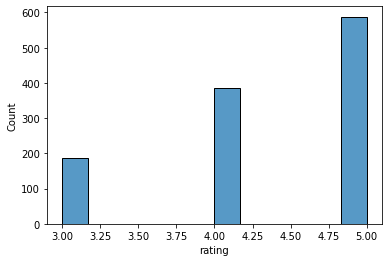

```python
sns.histplot(data = df2, x = 'rating');
```

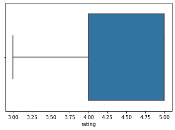

```python
sns.boxplot(data = df2, x = 'rating');
```

I have decided to treat `rating`'s missing values by replacing them with the most appropriate measure of center. Since the mean is noticeably less than the median, and the histogram and boxplot confirms that the distribution of `rating` is indeed left-skewed, I am choosing to stay away from the mean and replace `rating`'s missing values with the best measure of center: the median.

```python
# Find medians by Restaurant Name, Cuisine Type, and Day of the Week grouping variables
df2.groupby(['restaurant_name','cuisine_type','day_of_the_week'])[['rating']].median()
```

| restaurant_name | cuisine_type | day_of_the_week | rating |
| --- | --- | --- | --- |
| 'wichcraft | American | Weekday | 5.0 |
| 12 Chairs | Middle Eastern | Weekday | 4.5 |
|  |  | Weekend | NaN |
| 5 Napkin Burger | American | Weekday | NaN |
|  |  | Weekend | 4.0 |
| ... | ... | ... | ... |
| da Umberto | Italian | Weekday | 5.0 |
|  |  | Weekend | NaN |
| ilili Restaurant | Middle Eastern | Weekday | 4.0 |
|  |  | Weekend | 4.0 |
| indikitch | Indian | Weekend | 4.5 |

282 rows × 1 columns

```python
# Replace missing values with grouped medians
df2['rating'] = df2['rating'].fillna(value = df2.groupby(['restaurant_name','cuisine_type','day_of_the_week'])['rating'].transform('median'))
```

Since some of the grouped medians were `NaN`, then the above replacement did not get rid of all missing values in `rating`. So I will now explore `rating` again to decide what to do about the remaining missing values.

```python
# Exploring rating... take 2
pd.DataFrame({'Count':df2.isnull().sum()[df2.isnull().sum()>0],'Percentage':(df2.isnull().sum()[df2.isnull().sum()>0]/df2.shape[0])*100})
```

|  | Count | Percentage |
| --- | --- | --- |
| rating | 65 | 3.424658 |

```python
df2['rating'].describe().T
```

```
count    1833.000000
mean        4.363066
std         0.670507
min         3.000000
25%         4.000000
50%         4.000000
75%         5.000000
max         5.000000
Name: rating, dtype: float64
```

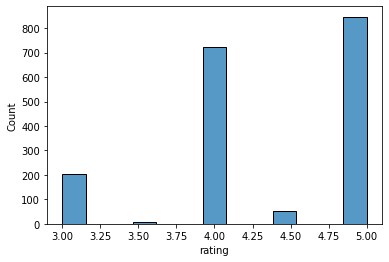

```python
sns.histplot(data = df2, x = 'rating');
```

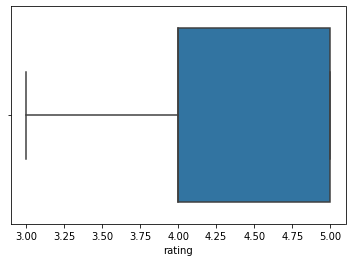

```python
sns.boxplot(data = df2, x = 'rating');
```

There are much fewer missing values. Now I must decide how to replace the missing values that were not treated by the grouping of the three categorical variables.

```python
# Find medians by Restaurant Name, Cuisine Type, and Day of the Week grouping variables; count how many of those medians are missing
df2.groupby(['restaurant_name','cuisine_type','day_of_the_week'])[['rating']].median().isnull().sum()
```

```
rating    49
dtype: int64
```

```python
# Find medians by Restaurant Name and Cuisine Type grouping variables ONLY; count how many of those medians are missing
df2.groupby(['restaurant_name','cuisine_type'])[['rating']].median().isnull().sum()
```

```
rating    22
dtype: int64
```

```python
# Find medians by Restaurant Name and Day of the Week grouping variables ONLY; count how many of those medians are missing
df2.groupby(['restaurant_name','day_of_the_week'])[['rating']].median().isnull().sum()
```

```
rating    49
dtype: int64
```

```python
# Find medians by Cuisine Type and Day of the Week grouping variables ONLY; count how many of those medians are missing
df2.groupby(['cuisine_type','day_of_the_week'])[['rating']].median().isnull().sum()
```

```
rating    1
dtype: int64
```

Regrouping by `cuisine_type` and `day_of_the_week` is the best option, so I will replace the next round of `rating` `NaN`s with those medians.

```python
# Replace missing values with regrouped medians
df2['rating'] = df2['rating'].fillna(value = df2.groupby(['cuisine_type', 'day_of_the_week'])['rating'].transform('median'))
```

Re-explore `rating`, and if there are still missing values,use `rating`'s overall median (with no groupings) for imputation.

```python
# Exploring rating... take 3
pd.DataFrame({'Count':df2.isnull().sum()[df2.isnull().sum()>0],'Percentage':(df2.isnull().sum()[df2.isnull().sum()>0]/df2.shape[0])*100})
```

|  | Count | Percentage |
| --- | --- | --- |
| rating | 1 | 0.052687 |

```python
# Find overall median rating
rating_med = df2['rating'].median()
rating_med
```

```
4.0
```

```python
# Replace missing value with overall median rating
df2['rating'] = df2['rating'].fillna(value = rating_med)
```

```python
# Should be no more missing values in the data frame
pd.DataFrame({'Count':df2.isnull().sum()[df2.isnull().sum()>0],'Percentage':(df2.isnull().sum()[df2.isnull().sum()>0]/df2.shape[0])*100})
```

|  | Count | Percentage |
| --- | --- | --- |

#### Observations:

After replacing "Not given" values in `rating` with `NaN` values, I wanted to convert `rating` to an integer type, as that seemed more appropriate for the integer rating system in place for the FoodHub app. However, converting to `int` threw an `IntCastingNaNError`, but converting to `float` did not.

### **Question 4:** Check the statistical summary of the data. What is the minimum, average, and maximum time it takes for food to be prepared once an order is placed? [2 marks]

```python
# Summarizing each column of data frame
df2.describe(include='all').T
```

|  | count | unique | top | freq | mean | std | min | 25% | 50% | 75% | max |
| --- | --- | --- | --- | --- | --- | --- | --- | --- | --- | --- | --- |
| order_id | 1898.0 | NaN | NaN | NaN | 1477495.5 | 548.049724 | 1476547.0 | 1477021.25 | 1477495.5 | 1477969.75 | 1478444.0 |
| customer_id | 1898.0 | NaN | NaN | NaN | 171168.478398 | 113698.139743 | 1311.0 | 77787.75 | 128600.0 | 270525.0 | 405334.0 |
| restaurant_name | 1898 | 178 | Shake Shack | 219 | NaN | NaN | NaN | NaN | NaN | NaN | NaN |
| cuisine_type | 1898 | 14 | American | 584 | NaN | NaN | NaN | NaN | NaN | NaN | NaN |
| cost_of_the_order | 1898.0 | NaN | NaN | NaN | 16.498851 | 7.483812 | 4.47 | 12.08 | 14.14 | 22.2975 | 35.41 |
| day_of_the_week | 1898 | 2 | Weekend | 1351 | NaN | NaN | NaN | NaN | NaN | NaN | NaN |
| rating | 1898.0 | NaN | NaN | NaN | 4.36736 | 0.666245 | 3.0 | 4.0 | 4.0 | 5.0 | 5.0 |
| food_preparation_time | 1898.0 | NaN | NaN | NaN | 27.37197 | 4.632481 | 20.0 | 23.0 | 27.0 | 31.0 | 35.0 |
| delivery_time | 1898.0 | NaN | NaN | NaN | 24.161749 | 4.972637 | 15.0 | 20.0 | 25.0 | 28.0 | 33.0 |

```python
# Summarizing food preparation time column only
df2['food_preparation_time'].describe()
```

```
count    1898.000000
mean       27.371970
std         4.632481
min        20.000000
25%        23.000000
50%        27.000000
75%        31.000000
max        35.000000
Name: food_preparation_time, dtype: float64
```

#### Alternate way: Finding minimum, average, and maximum times individually

```python
def min_sec_conv(dec_val):
  # This function converts a decimal value to minutes (integer) and seconds (integer).
  mins = int(np.floor(dec_val))
  secs = round((dec_val - mins) * 60)
  return [mins, secs]

# Minimum food preparation time (minutes)
fp_min = df2['food_preparation_time'].min()
print('Minimum food preparation time is', fp_min, 'minutes.')

# Mean (average) food preparation time (minutes)
fp_mean = df2['food_preparation_time'].mean()
[fp_mean_min, fp_mean_sec] = min_sec_conv(fp_mean)
print('Mean (average) food preparation time is approximately', fp_mean_min,
      'minutes and', fp_mean_sec, 'seconds.')

# Maximum food preparation time (minutes)
fp_max = df2['food_preparation_time'].max()
print('Maximum food preparation time is', fp_max, 'minutes.')
```

```
Minimum food preparation time is 20 minutes.
Mean (average) food preparation time is approximately 27 minutes and 22 seconds.
Maximum food preparation time is 35 minutes.
```

#### Observations:

The minimum food preparation time is 20 minutes. The mean food preparation time is 27.37197 minutes (approximately 27 minutes and 22 seconds). The maximum food preparation time is 35 minutes.

### **Question 5:** How many orders are not rated? [1 mark]

I chose to treat `rating = 'Not given'` as missing data in Question 3 (in the `df2` data frame) and therefore replaced them with appropriate median values. However, I can still use the original `df` data frame to demonstrate my understanding of how to determine the number of orders that were originally not rated.

```python
# Observe unique rating values
df['rating'].unique()
```

```
array(['Not given', '5', '3', '4'], dtype=object)
```

```python
# Obtain counts of occurrences of each unique rating value
df['rating'].value_counts()
```

```
Not given    736
5            588
4            386
3            188
Name: rating, dtype: int64
```

#### Observations:

There are 736 orders that were not rated (where the `rating` column had a value of "Not given").

### Exploratory Data Analysis (EDA)

### **Question 6:** Explore all the variables and provide observations on their distributions. (Generally, histograms, boxplots, countplots, etc. are used for univariate exploration.) [9 marks]

The `order_id` column is used as a unique identifier in the data set. Therefore, it is not necessary to explore this variable's distribution. We begin the exploration with the `customer_id` variable.

```python
df2['customer_id'].nunique()
```

```
1200
```

There are 1200 unique customers. We can use a Seaborn count plot to find the number of orders per customer.

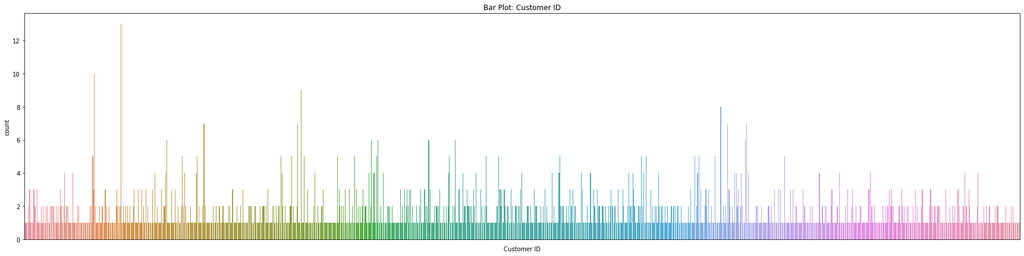

```python
plt.figure(figsize=(30,7));
cust = sns.countplot(data = df2, x = 'customer_id');
cust.set(title = 'Bar Plot: Customer ID', xlabel = 'Customer ID', xticklabels = [])
cust.tick_params(bottom=False)  # remove the x-axis ticks
```

Most FoodHub customers have only placed one to three orders with the app.

Next is `restaurant_name`.

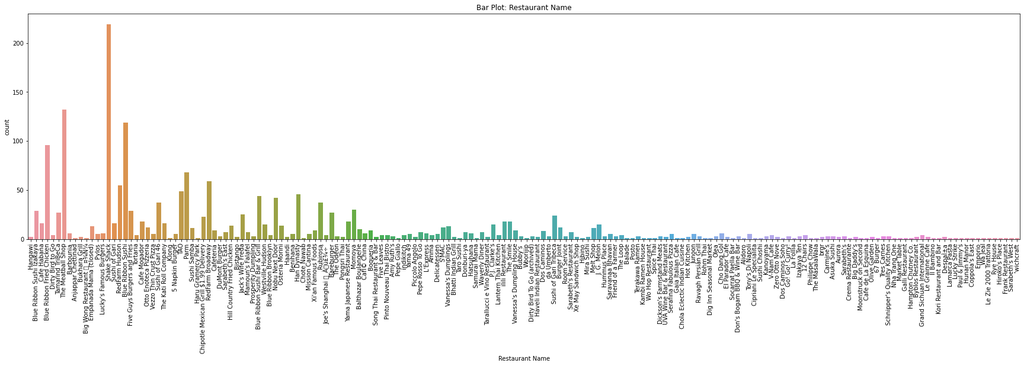

```python
plt.figure(figsize=(30,7));
res = sns.countplot(data = df2, x = 'restaurant_name');
res.set(title = 'Bar Plot: Restaurant Name', xlabel = 'Restaurant Name');
plt.xticks(rotation=90);
```

Most FoodHub restaurants have processed less than 50 orders from the app. Shake Shack is the restaurant that has processed the most orders, followed by The Meatball Shop and Blue Ribbon Sushi.

Next, we will analyze `cuisine_type`.

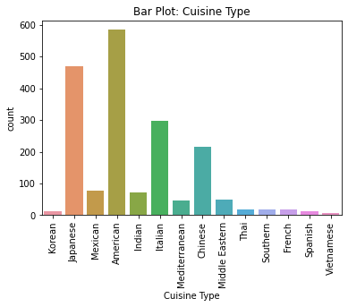

```python
cuis = sns.countplot(data = df2, x = 'cuisine_type');
cuis.set(title = 'Bar Plot: Cuisine Type', xlabel = 'Cuisine Type');
plt.xticks(rotation=90);
```

There are many cuisine types that are available for FoodHub customers. There are four types that are clear favorites: American, Japanese, Italian, and Chinese.

Next, let's explore `cost_of_the_order`.

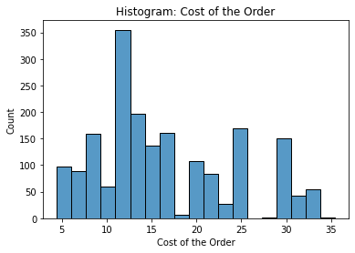

```python
cost1 = sns.histplot(data = df2, x = 'cost_of_the_order');
cost1.set(title = 'Histogram: Cost of the Order', xlabel = 'Cost of the Order');
```

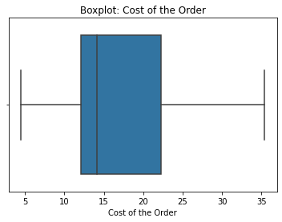

```python
cost2 = sns.boxplot(data = df2, x = 'cost_of_the_order');
cost2.set(title = 'Boxplot: Cost of the Order', xlabel = 'Cost of the Order');
```

This histogram shows the distribution of order costs. We see the main peak at approximately \$11-\$13, and the boxplot shows the median (50th percentile) at approximately $14. There are also other noticeable smaller peaks in the histogram. Overall, the histogram and boxplot both show that `cost_of_the_order` is right-skewed, as is often seen in the distribution of many currency variables involving price, cost, or income.

Next, we would like to examine `day_of_the_week`.

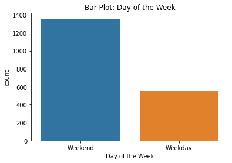

```python
d = sns.countplot(data = df2, x = 'day_of_the_week');
d.set(title = 'Bar Plot: Day of the Week', xlabel = 'Day of the Week');
```

The `day_of_the_week` variable only has two values: Weekend and Weekday. The bar plot shows the clear difference in number of orders. FoodHub members place over twice as many orders on weekends as they do on weekdays.

The next variable we would like to explore is `rating`.

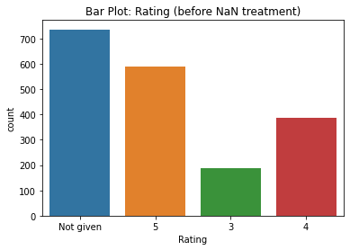

```python
rat1 = sns.countplot(data = df, x = 'rating');
rat1.set(title = 'Bar Plot: Rating (before NaN treatment)', xlabel = 'Rating');
```

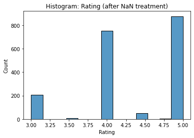

```python
rat2 = sns.histplot(data = df2, x = 'rating');
rat2.set(title = 'Histogram: Rating (after NaN treatment)', xlabel = 'Rating');
```

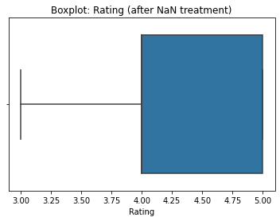

```python
rat3 = sns.boxplot(data = df2, x = 'rating');
rat3.set(title = 'Boxplot: Rating (after NaN treatment)', xlabel = 'Rating');
```

Let us next explore `food_preparation_time`.

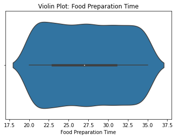

```python
f1 = sns.violinplot(data = df2, x = 'food_preparation_time');
f1.set(title = 'Violin Plot: Food Preparation Time', xlabel = 'Food Preparation Time');
```

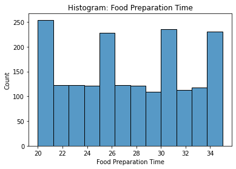

```python
f2 = sns.histplot(data = df2, x = 'food_preparation_time');
f2.set(title = 'Histogram: Food Preparation Time', xlabel = 'Food Preparation Time');
```

The violin plot for `food_preparation_time` combines the kernel density estimation with its boxplot. In this graph, we can see a symmetrical distribution, centered around approximately 26 minutes. After observing the histogram, we discover that the distribution is also multimodal.

Finally, we explore the distribution of `delivery_time`.

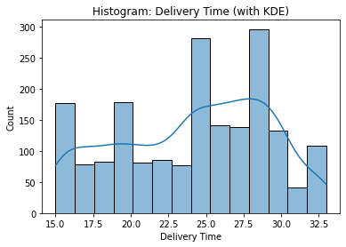

```python
deliv1 = sns.histplot(data = df2, x = 'delivery_time', kde=True);
deliv1.set(title = 'Histogram: Delivery Time (with KDE)', xlabel = 'Delivery Time');
```

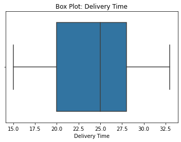

```python
deliv2 = sns.boxplot(data = df2, x = 'delivery_time');
deliv2.set(title = 'Box Plot: Delivery Time', xlabel = 'Delivery Time');
```

Delivery times are multimodal and slightly left-skewed. Its center is at the median of 25 minutes, with an interquartile range spread of approximately 8 minutes.

### **Question 7**: Which are the top 5 restaurants in terms of the number of orders received? [1 mark]

```python
df2['restaurant_name'].value_counts(ascending=False)[:5]
```

```
Shake Shack                  219
The Meatball Shop            132
Blue Ribbon Sushi            119
Blue Ribbon Fried Chicken     96
Parm                          68
Name: restaurant_name, dtype: int64
```

#### Observations:

The top 5 restaurants by number of orders received are:

1. Shake Shack
2. The Meatball Shop
3. Blue Ribbon Sushi
4. Blue Ribbon Fried Chicken
5. Parm

### **Question 8**: Which is the most popular cuisine on weekends? [1 mark]

```python
# Pandas series of number of weekend orders by cuisine type
weekends = df2.loc[df2['day_of_the_week'] == 'Weekend']
weekends['cuisine_type'].value_counts(ascending = False)
```

```
American          415
Japanese          335
Italian           207
Chinese           163
Mexican            53
Indian             49
Mediterranean      32
Middle Eastern     32
Thai               15
French             13
Korean             11
Southern           11
Spanish            11
Vietnamese          4
Name: cuisine_type, dtype: int64
```

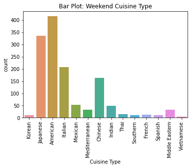

```python
# Seaborn bar plot of number of weekend orders by cuisine type
wknd_cuis1 = sns.countplot(data = weekends, x = 'cuisine_type');
wknd_cuis1.set(title = 'Bar Plot: Weekend Cuisine Type', xlabel = 'Cuisine Type');
plt.xticks(rotation=90);
```

```python
# Sort cuisine type descending by median weekend rating
weekends.groupby(['cuisine_type'])['rating'].median().sort_values(ascending=False)
```

```
cuisine_type
Indian            5.00
Italian           5.00
Mediterranean     5.00
Mexican           5.00
Spanish           5.00
Thai              5.00
Chinese           4.75
Vietnamese        4.75
French            4.50
Japanese          4.50
Southern          4.50
American          4.00
Korean            4.00
Middle Eastern    4.00
Name: rating, dtype: float64
```

### **Question 9**: What percentage of the orders cost more than 20 dollars? [2 marks]

```python
# Count rows of subset data frame such that order cost > 20
count_more_than_20 = df2.loc[df2['cost_of_the_order'] > 20].shape[0]
print("Number of orders that cost more than $20:", count_more_than_20)

# Divide that count by total count (all orders), multiply by 100 to get percentage
perc_more_than_20 = count_more_than_20 / df2.shape[0] * 100
print("Percentage of all orders that cost more than $20:", perc_more_than_20, "%")
```

```
Number of orders that cost more than $20: 555
Percentage of all orders that cost more than $20: 29.24130663856691 %
```

Alternate method: Using `pd.cut` and `value.counts()`

```python
# Cut cost_of_the_order into two categories: Less than or equal to 20 dollars, and More than 20 dollars
cost_cuts = pd.cut(x = df2['cost_of_the_order'], bins = [df2['cost_of_the_order'].min() - 1, 20, df2['cost_of_the_order'].max() + 1], labels = ['Less than or equal to 20 dollars', 'More than 20 dollars'], right = True)
cost_cuts.value_counts(normalize = True) * 100
```

```
Less than or equal to 20 dollars    70.758693
More than 20 dollars                29.241307
Name: cost_of_the_order, dtype: float64
```

#### Observations:

Approximately 29.24% of all FoodHub orders cost more than \$20.

### **Question 10**: What is the mean order delivery time? [1 mark]

```python
# Find mean delivery time, convert to minutes and seconds
del_time_mean = df2['delivery_time'].mean()
[del_time_mean_min, del_time_mean_sec] = min_sec_conv(del_time_mean)
print("The mean order delivery time is approximately", del_time_mean_min, "minutes and", del_time_mean_sec, "seconds.")
```

```
The mean order delivery time is approximately 24 minutes and 10 seconds.
```

#### Observations:

The mean order delivery time is approximately 24 minutes and 10 seconds.

### **Question 11:** The company has decided to give 20% discount vouchers to the top 5 most frequent customers. Find the IDs of these customers and the number of orders they placed. [1 mark]

```python
# Count number of orders for each customer, order series from largest to smallest number of orders, display top five only
df2['customer_id'].value_counts(ascending = False)[:5]
```

```
52832     13
47440     10
83287      9
250494     8
259341     7
Name: customer_id, dtype: int64
```

#### Observations:

The top five most frequent customers are: Customer ID #52832, with 13 orders; Customer ID #47440, with 10 orders; Customer ID #83287, with 9 orders; Customer ID #250494, with 8 orders; and Customer ID #259341, with 7 orders.

### **Question 12**: Perform a multivariate analysis to explore relationships between the important variables in the dataset. (It is a good idea to explore relations between numerical variables as well as relations between numerical and categorical variables) [10 marks]

First, we can perform a correlation analysis of the four numerical variables: `cost_of_the_order`, `rating`, `food_preparation_time`, and `delivery_time`.

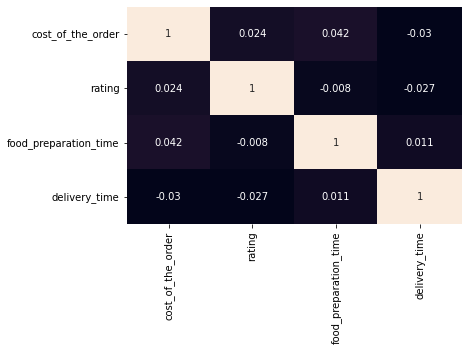

```python
# Correlation matrix for numerical variables
sns.heatmap(data = df2[['cost_of_the_order', 'rating', 'food_preparation_time', 'delivery_time']].corr(), annot = True, cbar = False);
```

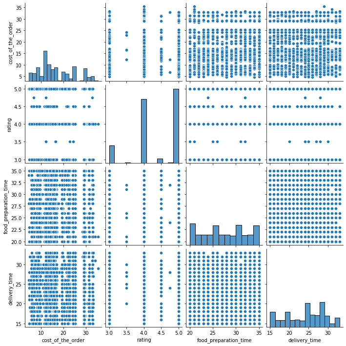

```python
sns.pairplot(data = df2[['cost_of_the_order', 'rating', 'food_preparation_time', 'delivery_time']]);
```

After observing the correlation values and pairplots between all numerical variables, it is clear that none of these four variables have any significant linear relationships with each other.

Next, we would like to analyze `cost_of_the_order`, by `cuisine_type` and `day_of_the_week`.

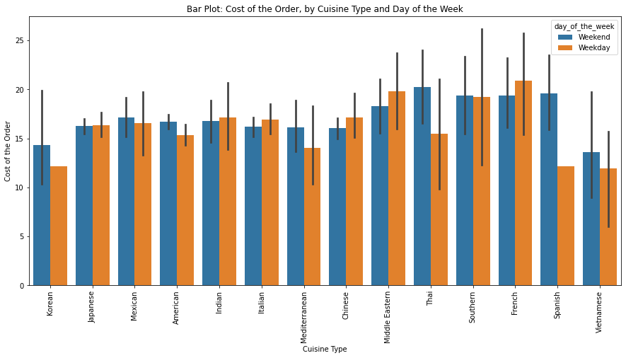

```python
plt.figure(figsize=(15,7));
viz1 = sns.barplot(data = df2, x = 'cuisine_type', y = 'cost_of_the_order', hue = 'day_of_the_week');
viz1.set(title = 'Bar Plot: Cost of the Order, by Cuisine Type and Day of the Week', xlabel = 'Cuisine Type', ylabel = 'Cost of the Order');
plt.xticks(rotation=90);
```

The above bar plot shows similar average costs of orders by cuisine type, when compared side-by-side by day of the week. In all but one cuisine type (Spanish), the 95% confidence interval bars for each cuisine type's weekend average cost of order overlaps with its weekday confidence interval. This means that there is not a significant difference in average costs of order for weekends and weekdays. However, with Spanish cuisine, weekend average cost of order significantly exceeds its weekday average.

Now we observe `rating`, by `cuisine_type` and `day_of_the_week`.

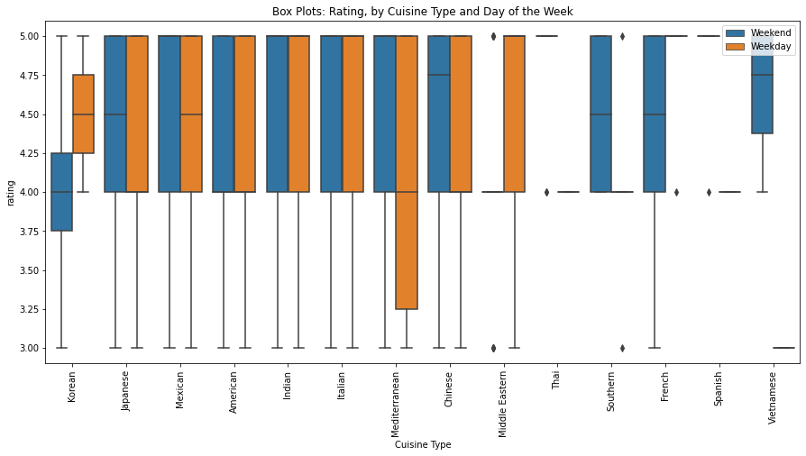

```python
plt.figure(figsize=(15,7));
viz2 = sns.boxplot(data=df2, x="cuisine_type", y="rating", hue="day_of_the_week");
viz2.set(title = 'Box Plots: Rating, by Cuisine Type and Day of the Week', xlabel = 'Cuisine Type');
plt.xticks(rotation=90);
plt.legend(loc='best');
```

We now continue with an analysis of `food_preparation_time`, by `cuisine_type` and `day_of_the_week`.

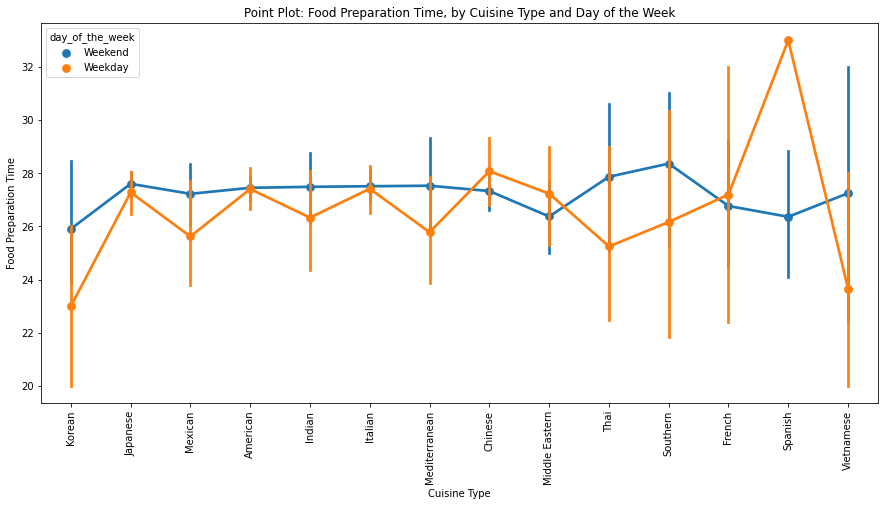

```python
plt.figure(figsize=(15,7));
viz3 = sns.pointplot(data = df2, x = 'cuisine_type', y = 'food_preparation_time', hue = 'day_of_the_week');
viz3.set(title = 'Point Plot: Food Preparation Time, by Cuisine Type and Day of the Week', xlabel = 'Cuisine Type', ylabel = 'Food Preparation Time');
plt.xticks(rotation=90);
```

With this point plot, we can observe each cuisine type's average food preparation time, with their 95% confidence interval estimates. When we compare each cuisine type's weekday confidence interval with its weekend confidence interval, we have overlap (meaning, no significant difference in average food preparation time) for all cuisine types except for Spanish cuisine. With Spanish cuisine, we observe that the weekday average food preparation time is significantly higher than its weekend average. This weekday average for Spanish cuisine is also the highest of all cuisine types, with the lowest averages belonging to Korean and Vietnamese cuisines. Weekend average times show less variation among cuisine types, as weekday average times fluctuate much more for various cuisine types.

Now, let's look at `delivery_time`, by `cuisine_type` and `day_of_the_week`.

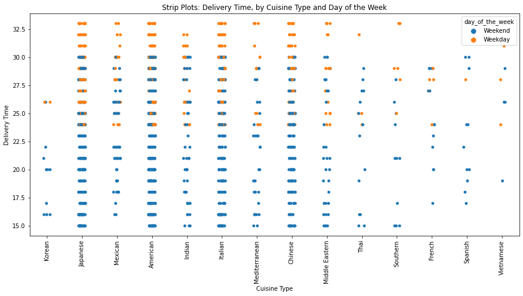

```python
plt.figure(figsize=(15,7));
viz4 = sns.stripplot(data = df2, x = 'cuisine_type', y = 'delivery_time', hue = 'day_of_the_week');
viz4.set(title = 'Strip Plots: Delivery Time, by Cuisine Type and Day of the Week', xlabel = 'Cuisine Type', ylabel = 'Delivery Time');
plt.xticks(rotation=90);
```

I originally wanted to show this with a swarm plot, but there were so many points to plot, the only way to fit all points on the plot was to widen the figure size to its maximum horizontal distance AND reduce the point size. This made the plot very hard to see. So, to reduce eye strain, I chose a strip plot instead. This means that there are lots of points here that overlap, but we can still understand the overall insights of the relationships here.

Notice that the distributions of weekend delivery times for each cuisine type show much more variation compared to its corresponding weekday times. While weekday delivery times have less spread in comparison to weekends, its distribution ranges on the higher end of all delivery times represented.

### **Question 13:** The company wants to provide a promotional offer in the advertisement of the restaurants. The condition to get the offer is that the restaurants must have a rating count of more than 50 and the average rating should be greater than 4. Find the restaurants fulfilling the criteria to get the promotional offer. [3 marks]

```python
# Query all restaurants with non-"Not given" rating counts greater than 50
rest_rat_counts = df.loc[df['rating'] != "Not given"].groupby('restaurant_name', as_index = False)['rating'].count()
rest_rat_counts_greater_50 = rest_rat_counts.loc[rest_rat_counts['rating'] > 50]
rest_rat_counts_greater_50
```

|  | restaurant_name | rating |
| --- | --- | --- |
| 16 | Blue Ribbon Fried Chicken | 64 |
| 17 | Blue Ribbon Sushi | 73 |
| 117 | Shake Shack | 133 |
| 132 | The Meatball Shop | 84 |

```python
# Filter by non-"Not given" ratings; convert remaining rating column to type int
rest_valid_rat = df.loc[df['rating'] != "Not given"].copy()
rest_valid_rat['rating'] = rest_valid_rat['rating'].astype(int)
rest_valid_rat.info()

# Query all restaurants with average ratings greater than 4
rest_rat_means = rest_valid_rat.groupby('restaurant_name', as_index = False)['rating'].mean()
rest_rat_means_greater_4 = rest_rat_means.loc[rest_rat_means['rating'] > 4]
rest_rat_means_greater_4
```

```
<class 'pandas.core.frame.DataFrame'>
Int64Index: 1162 entries, 2 to 1896
Data columns (total 9 columns):
 #   Column                 Non-Null Count  Dtype
---  ------                 --------------  -----
 0   order_id               1162 non-null   int64
 1   customer_id            1162 non-null   int64
 2   restaurant_name        1162 non-null   object
 3   cuisine_type           1162 non-null   object
 4   cost_of_the_order      1162 non-null   float64
 5   day_of_the_week        1162 non-null   object
 6   rating                 1162 non-null   int64
 7   food_preparation_time  1162 non-null   int64
 8   delivery_time          1162 non-null   int64
dtypes: float64(1), int64(5), object(3)
memory usage: 90.8+ KB
```

|  | restaurant_name | rating |
| --- | --- | --- |
| 0 | 'wichcraft | 5.000000 |
| 1 | 12 Chairs | 4.500000 |
| 3 | 67 Burger | 5.000000 |
| 4 | Amma | 4.500000 |
| 6 | Anjappar Chettinad | 5.000000 |
| ... | ... | ... |
| 149 | Yama 49 | 5.000000 |
| 150 | Yama Japanese Restaurant | 4.500000 |
| 153 | da Umberto | 5.000000 |
| 154 | ilili Restaurant | 4.153846 |
| 155 | indikitch | 4.500000 |

110 rows × 2 columns

```python
# Inner join the two previous query data frames to see which restaurants qualify for the promotional offer
promo_offer = pd.merge(rest_rat_counts_greater_50, rest_rat_means_greater_4, how='inner', on='restaurant_name')
promo_offer = promo_offer.rename(columns={'rating_x': 'rating_count', 'rating_y': 'rating_avg'})
promo_offer
```

|  | restaurant_name | rating_count | rating_avg |
| --- | --- | --- | --- |
| 0 | Blue Ribbon Fried Chicken | 64 | 4.328125 |
| 1 | Blue Ribbon Sushi | 73 | 4.219178 |
| 2 | Shake Shack | 133 | 4.278195 |
| 3 | The Meatball Shop | 84 | 4.511905 |

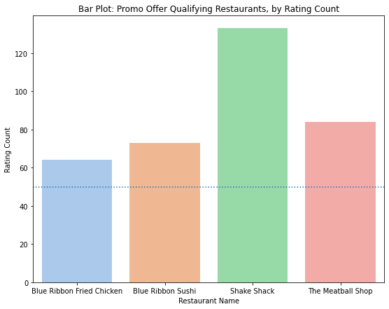

```python
# Show bar plot for restaurants who meet rating count qualification
plt.figure(figsize=(9,7));
rat_count_plot = sns.barplot(data = promo_offer, x = 'restaurant_name', y = 'rating_count', palette = 'pastel');
rat_count_plot.axhline(50, linestyle = 'dotted')
rat_count_plot.set(title = 'Bar Plot: Promo Offer Qualifying Restaurants, by Rating Count', xlabel = 'Restaurant Name', ylabel = 'Rating Count');
```

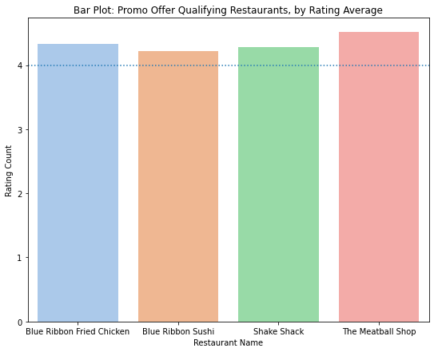

```python
# Show bar plot for restaurants who meet rating average qualification
plt.figure(figsize=(9,7));
rat_count_plot = sns.barplot(data = promo_offer, x = 'restaurant_name', y = 'rating_avg', palette = 'pastel');
rat_count_plot.axhline(4, linestyle = 'dotted')
rat_count_plot.set(title = 'Bar Plot: Promo Offer Qualifying Restaurants, by Rating Average', xlabel = 'Restaurant Name', ylabel = 'Rating Count');
```

#### Observations:

The restaurants that qualify for the promotional offer are Blue Ribbon Fried Chicken, Blue Ribbon Sushi, Shake Shack, and The Meatball Shop.

### **Question 14:** The company charges the restaurant 25% on the orders having cost greater than 20 dollars and 15% on the orders having cost greater than 5 dollars. Find the net revenue generated by the company across all orders. [3 marks]

```python
# Create function that will calculate FoodHub restaurant charges
def rev(s):
  if s > 20:
    return round(s*0.25, 2) # 25% FoodHub charge (order costs greater than $20)
  elif s > 5 and s <= 20:
    return round(s*0.15, 2) # 15% FoodHub charge (order costs greater than $5 but less than or equal to $20)
  else:
    return 0

# Create new column in data frame for FoodHub's restaurant charges for orders with costs greater than $5
df2['revenue'] = df2['cost_of_the_order'].apply(rev)

# Find total net revenue for FoodHub
total_net_rev = df2['revenue'].sum()
total_net_rev
```

```
6166.5
```

#### Observations:

FoodHub generates a net revenue of \$6,166.50 across all orders.

### **Question 15:** The company wants to analyze the total time required to deliver the food. What percentage of orders take more than 60 minutes to get delivered from the time the order is placed? (The food has to be prepared and then delivered.) [2 marks]

```python
# Create new data frame column for total time from placement of order to delivery of order
df2['total_time'] = df2['food_preparation_time'] + df2['delivery_time']

# Calculate percentage of all orders where total time > 60 minutes
perc_tot_time_greater_60 = df2.loc[df2['total_time'] > 60].shape[0] / df2.shape[0] * 100
print("Approximately", perc_tot_time_greater_60, "% of all orders take more than 60 minutes to get delivered from the time the order is placed.")
```

```
Approximately 10.537407797681771 % of all orders take more than 60 minutes to get delivered from the time the order is placed.
```

Alternate method: Using `pd.cut` and `value.counts()`

```python
# Cut total_time into two categories: Less than or equal to 60 minutes, and More than 60 minutes
total_time_cuts = pd.cut(x = df2['total_time'], bins = [df2['total_time'].min() - 1, 60, df2['total_time'].max() + 1], labels = ['Less than or equal to 60 minutes', 'More than 60 minutes'], right = True)
total_time_cuts.value_counts(normalize = True) * 100
```

```
Less than or equal to 60 minutes    89.462592
More than 60 minutes                10.537408
Name: total_time, dtype: float64
```

#### Observations:

Approximately 10.54% of all orders take more than 60 minutes to get delivered from the time the order is placed.

### **Question 16:** The company wants to analyze the delivery time of the orders on weekdays and weekends. How does the mean delivery time vary during weekdays and weekends? [2 marks]

```python
# Group the data by day of the week, find delivery time averages
mean_deliv = df2.groupby('day_of_the_week', as_index = False)['delivery_time'].mean()
mean_deliv
```

|  | day_of_the_week | delivery_time |
| --- | --- | --- |
| 0 | Weekday | 28.340037 |
| 1 | Weekend | 22.470022 |

```python
# Convert weekday mean delivery time to minutes and seconds
mean_del_time_wkdy = mean_deliv.iloc[0,1]
[mean_del_time_wkdy_min, mean_del_time_wkdy_sec] = min_sec_conv(mean_del_time_wkdy)

# Convert weekend mean delivery time to minutes and seconds
mean_del_time_wknd = mean_deliv.iloc[1,1]
[mean_del_time_wknd_min, mean_del_time_wknd_sec] = min_sec_conv(mean_del_time_wknd)

print("The mean order delivery time for weekdays is approximately", mean_del_time_wkdy_min, "minutes and", mean_del_time_wkdy_sec, "seconds.")
print("The mean order delivery time for weekends is approximately", mean_del_time_wknd_min, "minutes and", mean_del_time_wknd_sec, "seconds.")
```

```
The mean order delivery time for weekdays is approximately 28 minutes and 20 seconds.
The mean order delivery time for weekends is approximately 22 minutes and 28 seconds.
```

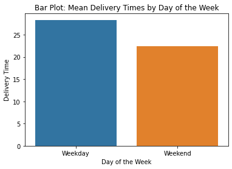

```python
# Bar plot of delivery times by day of the week
md = sns.barplot(data = mean_deliv, x = "day_of_the_week", y = "delivery_time");
md.set(title = "Bar Plot: Mean Delivery Times by Day of the Week", xlabel = "Day of the Week", ylabel = "Delivery Time");
```